# 10_microbe_explore

2024-05-31

# Overview

A quick exploration of the microbial data so far.

**Amplicon sequencing:**

A single library has been sequenced so far with 57 Lahaina samples in it. This includes samples from 10/08/2023 (initial trip), 11/13/2023 (pre-rain control + instrument deployment), 12/02/2023 (small rain event). Also included 2 field blanks (lcms water in 3X rinsed collection bottle or niskin. There are also sterivex blanks for this run associated with another project, which could be included as additional extraction blanks.

**Flow cytometry:** Flow cytometry has been run for most samples (total 98), which includes all samples up to the recent May sampling effort. Flow cytometry samples were not collected on the first trip (October), so we only have one pre-rain sampling trip to compare to. The May trip may be especially informative as a follow up low rain sampling event.

**fDOM:**

fDOM has been run for almost all samples (total 133), including all samples prior to the recent May sampling effort.

Main questions:

- are there site related differences?
- are there date/trip/rainfall related differences?

Spoiler: after making some plots, I think there are some patterns worth digging into.

# 16S Data

## Ordinations

Plots to visualize broad categorical trends in the data.

We mainly expect to see broad categorical change across sites as a result of rainfall. This data set might not produce super exciting ordinations. We only have 16S data for the pre-rain and minor-rain samples.

There are probably be a lot of site specific effects that change how sites react to increased rainfall. We may eventually want to look at things like tide and time of day. We might also want to quantify likely input of surface water at these sites (by proximity, sensors, models, or otherwise).

```r
library(ggplot2)
library(data.table)
library(vegan)
library(ComplexHeatmap)
# read in
otu = fread("data/raw/dna/lahaina_round1_otu_table.csv")
tax = fread("data/raw/dna/lahaina_round1_taxonomy.csv")

unifrac = as.matrix(read.csv("data/raw/dna/lahaina_round1_unifrac.csv"))
row.names(unifrac) = colnames(unifrac)

sample_sheet = fread("data/clean/clean_all_data.csv")
site_sheet = fread("data/raw/meta/Lahaina Sample Collection Sheet - Sites.csv")
```

```r
# format date
sample_sheet$posix = as.POSIXct(as.character(sample_sheet$date),
                    format = "%Y%m%d")


# set up colors
theme_set(theme_minimal())
options(
  ggplot2.discrete.colour = c(
    '#e6194b',
    '#3cb44b',
    '#ffe119',
    '#4363d8',
    '#f58231',
    '#911eb4',
    '#46f0f0',
    '#f032e6',
    '#bcf60c',
    '#fabebe',
    '#008080',
    '#e6beff',
    '#9a6324',
    '#fffac8',
    '#800000',
    '#aaffc3',
    '#808000',
    '#ffd8b1',
    '#000075',
    '#808080',
    '#ffffff',
    '#000000'
  )
)

color_pallete = c(
'Mala point' = "green2",
'distance 1 - near shore' = "brown",
'distance 2' = "yellow",
'distance 3' = "lightblue",
'distance 4' = "blue",
'distance 5 - channel' = "darkblue",
'Kahoma stream' = "darkblue",
'Mala mooring' = "green3",
'Kahekili' = "gray",
'Kahoma outflow beach' = "darkblue",
'Kauaula stream bridge' = "cornflowerblue",
'Shark pit' = "darkorange",
'Ferry pier' = "purple4",
'Harbor' = "purple",
'Baby beach' = "green4",
'Mala Tavern' = "goldenrod",
'Wahikuli' = "yellow",
'Olowalu beach' = "black",

# trips
'Immediate post-fire' = "gray90",
'October: pre-rain' = "gray80" ,
'December: minor rain event' = "orange",
'January: post-major rain' = "salmon",
'November: pre-rain' = "pink",
'January: major rain event' = "orange4",
'May: spring quarterly sampling' = "cornflowerblue"
)
```

```r
# ordination function
ord_samples = function(samps){
  set.seed(2024)
  samps = samps[samps %in% rownames(unifrac)]
  dist_mat = unifrac[samps,samps]
  capture.output(ord <- metaMDS(comm = as.dist(dist_mat)))
  out = list(points = as.data.table(ord$points, keep.rownames = "collection"),
             stress = round(ord$stress, 3))
  return(out)
}


plot_ord = function(ord_out,
                    p_title= NULL,
                    color_var = NULL,
                    shape_var = NULL){

 points = ord_out$points
 ord_meta = merge(points, sample_sheet, by = "collection")

 if(is.null(color_var)){
   pal = "gray30"
 }else{
   col_class = class(sample_sheet[[color_var]])

   if(col_class %in% c("character", "factor")){
    pal = color_pallete[unique(sample_sheet[[color_var]])]
    sc = scale_color_manual(values = pal)
   }else{
     sc =   scale_colour_gradientn(colours = c("darkred",
                                               "orange",
                                               "gold"))
   }
 }

 ggplot(ord_meta, aes_string(x = "MDS1",
                             y = "MDS2",
                             color = color_var,
                             shape = shape_var))+
   geom_point(size = 3, alpha = 0.7)+
   sc+
   labs(title = p_title,
        caption = paste("Stress =", ord_out$stress))
}
```

### Library Overview

First, a big ordination with all of the various samples that we sequenced from Lahaina.

There’s not much to interpret here, but freshwater samples and a few others separate out from the bulk of the samples.

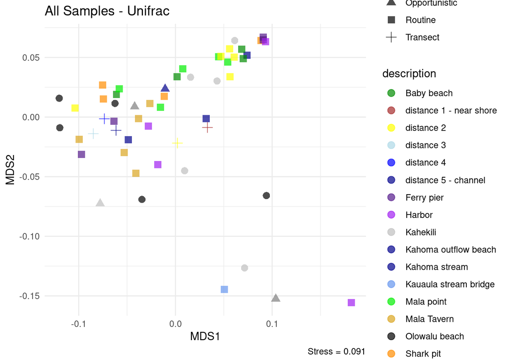

```r
all_ord = ord_samples(sample_sheet[ , collection])

plot_ord(all_ord,
         p_title = "All Samples - Unifrac",
         shape_var = "station_category",
         color_var = "description")
```

### Shoreline Samples

These are two NMDS ordination plots showing all shoreline samples that have been sequenced so far.

- Plot 1: variation by site
- Plot 2: variation by trip

Interpretation:

There are two outliers that make these plots less than ideal (stress is pretty low)

Despite the outliers, I do see some interesting things shifting by trip (i.e. rain) and site. While not super exciting, these ordinations give me some hope.

- Most post-rain samples are on the right side of the plot
- most pre-rain samples are on the left side of the plot
- Mala tavern seems to look like a rainy site all the time (there is a storm drain right there)

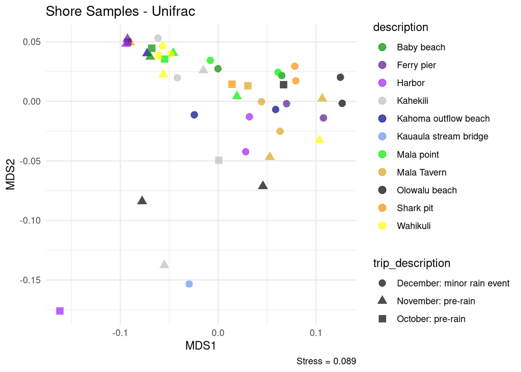

```r
# pull out all shore samples
shore_ord = ord_samples(sample_sheet[station_category %in% c("Routine", "Control"), collection])

plot_ord(shore_ord,
         p_title = "Shore Samples - Unifrac",
         color_var = "description",
         shape_var = "trip_description")
```

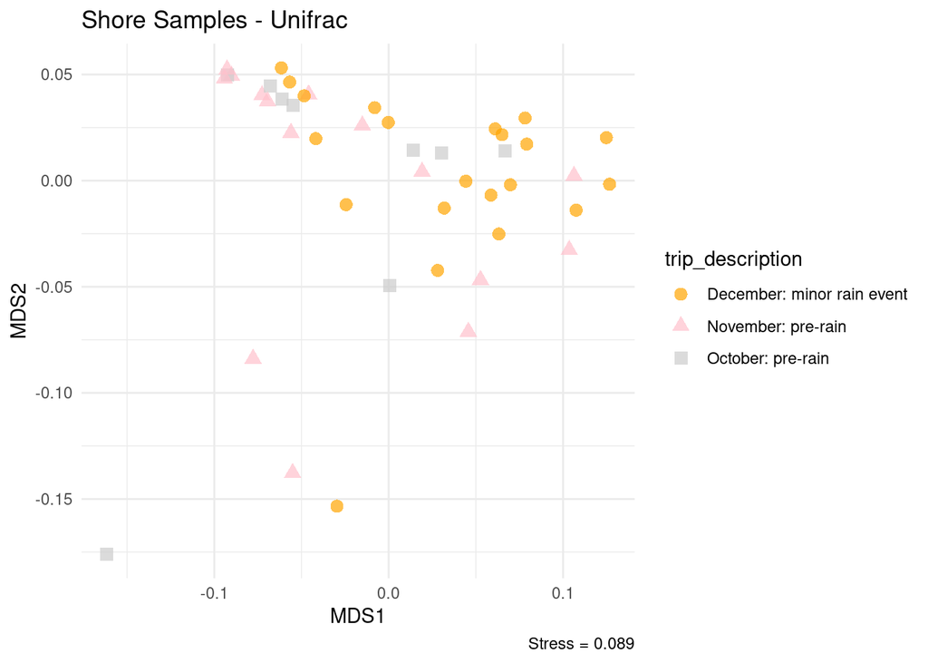

```r
ggsave("plots/dna/all_shore_samples_by_site.pdf",
       width = 7, height = 5,
       scale = 0.7)

plot_ord(shore_ord,
         p_title = "Shore Samples - Unifrac",
         color_var = "trip_description",
         shape_var = "trip_description")
```

```r
ggsave("plots/dna/all_shore_samples_by_trip.pdf",
       width = 7, height = 5,
       scale = 0.7)
```

### Shoreline - Outliers Dropped

- Plot 1: variation by site
- Plot 2: variation by trip

Interpretation:

Same as above, but patterns are a little more clear.

- minor rain event samples separate out from pre-rain samples
- minor rain event samples are pretty dispersed, indicating potentially more variation in the communities (as opposed to a more homogenous ocean microbial community, I would guess)

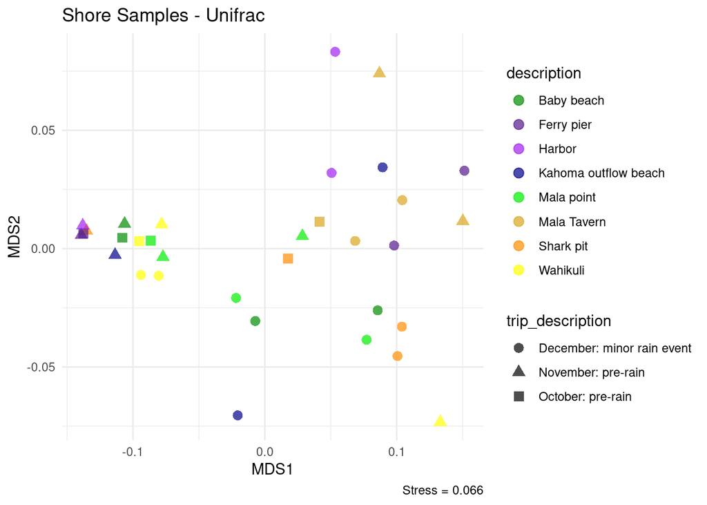

```r
clean_shore_ord = ord_samples(sample_sheet[station_category == "Routine" &
                                        !(collection %in% c("SH11_20231202", "SH3_20231008")),
                                        collection])

plot_ord(clean_shore_ord,
         p_title = "Shore Samples - Unifrac",
         color_var = "description",
         shape_var = "trip_description")
```

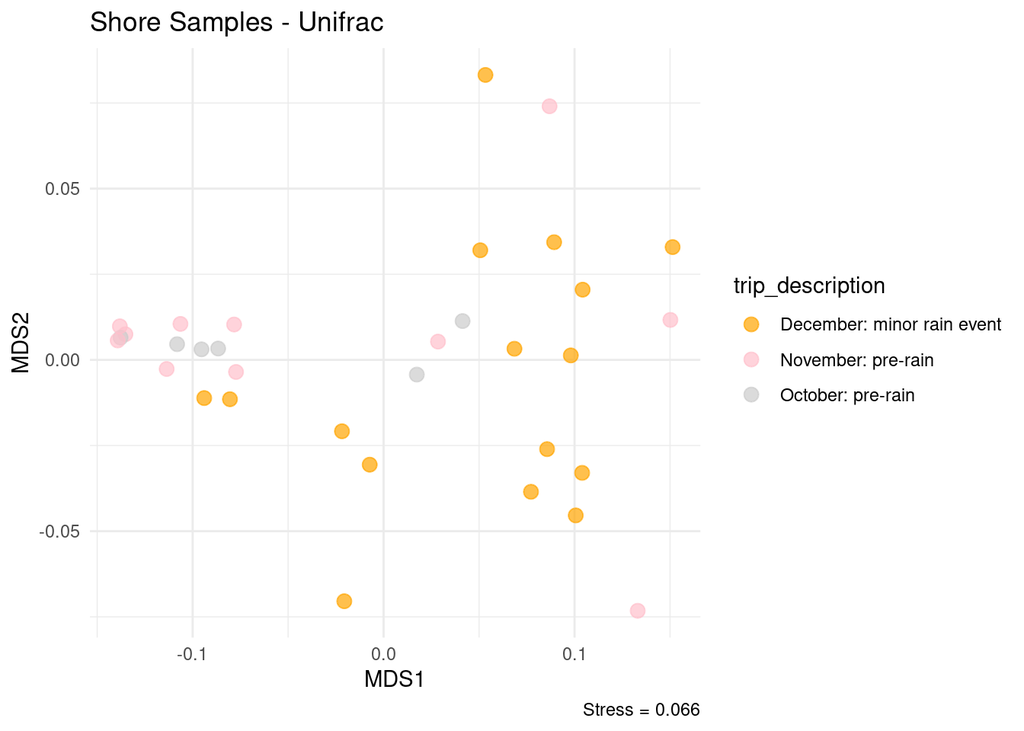

```r
plot_ord(clean_shore_ord,
         p_title = "Shore Samples - Unifrac",
         color_var = "trip_description")
```

## Heatmaps

Let’s make a heatmap to see if we can identify specific microbes that are varying across sites/trips.

```r
# function to sum by family
prep_ht_mat = function(otus,
                      tax_table,
                      tax_level = "family",
                      cutoff = 40,
                      min_sam = 2,
                      scale_vals = F){
  if(tax_level == "OTU"){
    otu_sum = otus

  }else{
  otu_key = merge(otus,
                    tax_table[,
                              .SD,
                              .SDcols = c(tax_level, "OTU")],
                    by = "OTU",
                    all.x = T)

  otu_key[, OTU := NULL]

  # sum by tax level
  otu_sum = otu_key[, lapply(.SD, sum), by = tax_level]
  }

  # order by most abundant taxa and subset to top N
  otu_sum[ , tax_sums := rowSums(otu_sum[ , .SD, .SDcols = !tax_level])]
  otu_sum = otu_sum[tax_sums > 0]
  otu_sum = otu_sum[order(tax_sums, decreasing = T)]
  otu_sum[ , tax_sums := NULL]
  otu_sum = otu_sum[1:cutoff,]

  # transform data.table to matrix
  otu_mat = as.matrix(otu_sum[, .SD,
                              .SDcols = !tax_level],
                      rownames.value = otu_sum[[tax_level]])

  # drop taxa that don't meet min sample count
  keep_tax = apply(otu_mat, 1, function(x)
    length(x[x > 0]) > min_sam)
  otu_mat = otu_mat[keep_tax, ]

  # optionally z-score a.k.a. scale values
  if (isTRUE(scale_vals)) {
    otu_mat = t(scale(t(otu_mat)))
  }

  return(otu_mat)
}
```

### Shoreline Samples

Heatmaps of all shoreline samples (summed by bacterial family, top 40)

- Plot 1: Top 40 bacterial families, z-scored, bottom annotations indicate sampling trip and site.
- Plot 2: Same, but with kauaula stream and outlier harbor sample dropped.
- Plot 3: This time, also include control sites Olowalu and Kahekili

Interpretation:

Yep, looks like we get very clear runoff signal in the microbes for samples collected during the minor rain event.

- Two obvious boxes of microbes
- Top left = normal ocean microbes
- Bottom right = runoff microbes (e.g. flavos)

Some noteworthy stuff happening in a couple samples

- outlier harbor right after the fire has different microbes in it (makes sense, oil spill)
- kauaula stream freshwater sample has different microbes in it
- harbor samples post- minor rain still look noticeably different from other samples (plot 2)
- possibly harbor and mala tavern samples can tell us what microbes to focus on for fire runoff signal (alteromonadaceae, psudoalteromonadaceae, vibrionaceae)

Controls seem okay although I get the impression Olowalu and Kahekili might have more going on than we’d really like in an ideal control site.

- Generally, olowalu and kahekili look similar microbially to our burn zone samples
- One olowalu sample has it’s own set of weird microbes in it
- Kahekili seems very susceptible to freshwater inputs

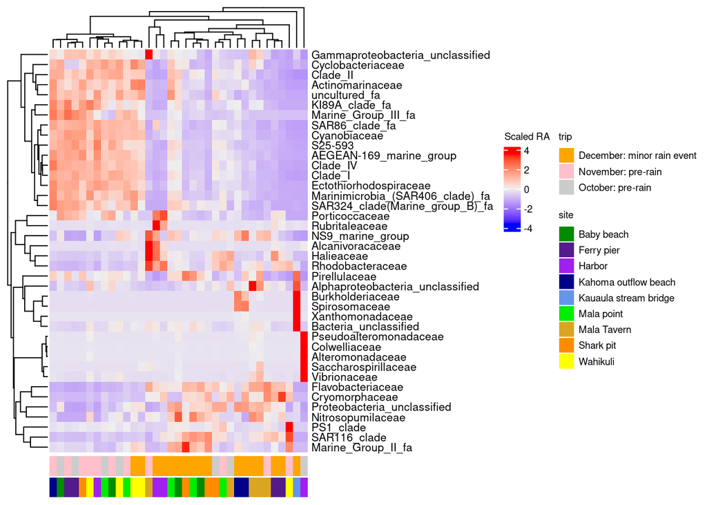

```r
shore_samples = sample_sheet[station_category == "Routine",
                                      collection]

shore_samples = shore_samples[shore_samples %in% colnames(otu)]


shore_otu = otu[, .SD, ,.SDcols = c("OTU",shore_samples)]

# get family summed matrix
shore_mat = prep_ht_mat(otu = shore_otu,
           tax_table = tax,
           tax_level = "family",
           cutoff = 40,
           scale_vals = T)

# make heatmap annotation
sites = sample_sheet[match(colnames(shore_mat),
                           sample_sheet$collection),
                     description]

trips = sample_sheet[match(colnames(shore_mat),
                           sample_sheet$collection),
                     trip_description]

ha = HeatmapAnnotation(
  trip = trips,
  site = sites,
  col = list(trip = color_pallete[unique(trips)],
             site = color_pallete[unique(sites)]),
  show_annotation_name = F,
  annotation_legend_param = list(
    labels_gp = gpar(fontsize = 7),
    title_gp = gpar(fontsize = 7)
  )
)

ht = Heatmap(
  matrix = shore_mat,
  bottom_annotation = ha,
  row_names_gp = gpar(fontsize = 8),
  show_column_names = F,
  heatmap_legend_param = list(
    labels_gp = gpar(fontsize = 7),
    title_gp = gpar(fontsize = 7),
    title = "Scaled RA"
  )
)
ht
```

### Shoreline Samples - outliers dropped

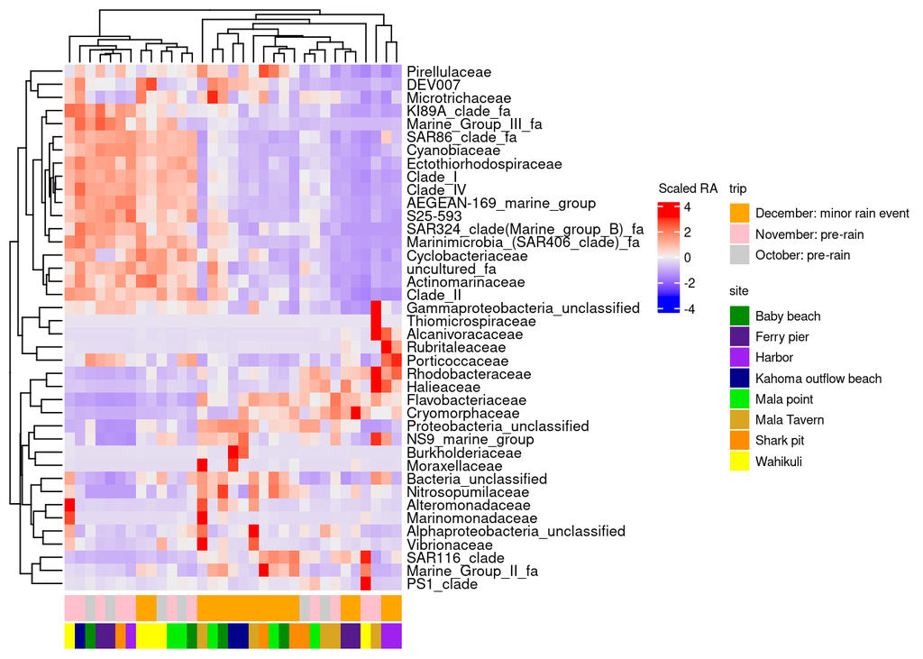

```r
clean_shore_otu = shore_otu[ , .SD, .SDcols = !c("SH11_20231202", "SH3_20231008")]

# get family summed matrix
shore_mat = prep_ht_mat(otu = clean_shore_otu,
           tax_table = tax,
           tax_level = "family",
           cutoff = 40,
           scale_vals = T)

# make heatmap annotation
sites = sample_sheet[match(colnames(shore_mat),
                           sample_sheet$collection),
                     description]

trips = sample_sheet[match(colnames(shore_mat),
                           sample_sheet$collection),
                     trip_description]

ha = HeatmapAnnotation(
  trip = trips,
  site = sites,
  col = list(trip = color_pallete[unique(trips)],
             site = color_pallete[unique(sites)]),
  show_annotation_name = F,
  annotation_legend_param = list(
    labels_gp = gpar(fontsize = 7),
    title_gp = gpar(fontsize = 7)
  )
)

ht = Heatmap(
  matrix = shore_mat,
  bottom_annotation = ha,
  row_names_gp = gpar(fontsize = 8),
  show_column_names = F,
  heatmap_legend_param = list(
    labels_gp = gpar(fontsize = 7),
    title_gp = gpar(fontsize = 7),
    title = "Scaled RA"
  )
)
ht
```

### Shoreline Samples - Controls

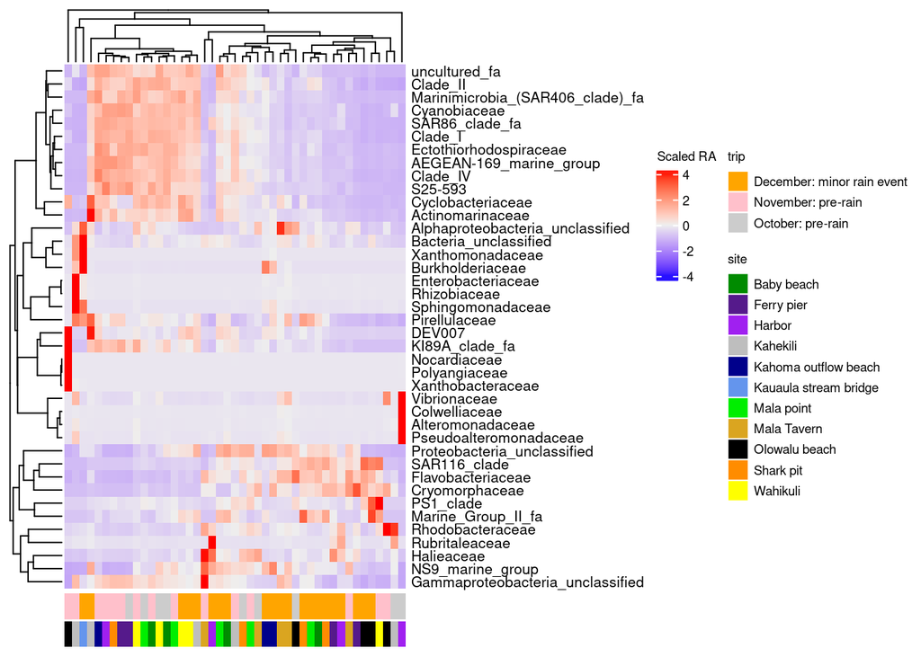

```r
shore_control_samples = sample_sheet[station_category %in% c("Routine", "Control"),
                                      collection]

shore_control_samples = shore_control_samples[shore_control_samples %in% colnames(otu)]


shore_control_otu = otu[, .SD, ,.SDcols = c("OTU",shore_control_samples)]

# get family summed matrix
shore_mat = prep_ht_mat(otu = shore_control_otu,
           tax_table = tax,
           tax_level = "family",
           cutoff = 40,
           scale_vals = T)

# make heatmap annotation
sites = sample_sheet[match(colnames(shore_mat),
                           sample_sheet$collection),
                     description]

trips = sample_sheet[match(colnames(shore_mat),
                           sample_sheet$collection),
                     trip_description]

ha = HeatmapAnnotation(
  trip = trips,
  site = sites,
  col = list(trip = color_pallete[unique(trips)],
             site = color_pallete[unique(sites)]),
  show_annotation_name = F,
  annotation_legend_param = list(
    labels_gp = gpar(fontsize = 7),
    title_gp = gpar(fontsize = 7)
  )
)

ht = Heatmap(
  matrix = shore_mat,
  bottom_annotation = ha,
  row_names_gp = gpar(fontsize = 8),
  show_column_names = F,
  heatmap_legend_param = list(
    labels_gp = gpar(fontsize = 7),
    title_gp = gpar(fontsize = 7),
    title = "Scaled RA"
  )
)
ht
```

# Flow Cytometry

Let’s see if anything jumps out from the flow cytometry data

## Boxplots

### Shoreline Samples

Plots 1-4: microbes per µl at each site across all dates for heterotrophic bacteria, synechococcus, prochlorococcus, and pico eukaryotes

Interpretation:

- No clear correlation between heterotrophic bacteria and rain event. Some variability by site. Ferry/Harbor/shark pit are the highest in the burn zone. Olowalu pretty high too!
- Maybe something going on with post-major rain and synechococcus (plot 2)
- Something weird going on at shark pit with pico eukaryotes?

```r
shore_dat = sample_sheet[station_category %in% c("Routine", "Control")]
shore_sites = site_sheet[station %in% shore_dat$station]


# set site factors to plot north to south
shore_dat$description = factor(shore_dat$description,
                               levels = shore_sites$description[order(shore_sites$lat)])
shore_dat$station = factor(shore_dat$station,
                           levels = shore_sites$station[order(shore_sites$lat)])

# set date factors
date_levels = c('October: pre-rain',
'November: pre-rain',
'December: minor rain event',
'January: major rain event',
'January: post-major rain',
'May: spring quarterly sampling')

shore_dat$trip_description = factor(shore_dat$trip_description,
                                    levels = date_levels)
```

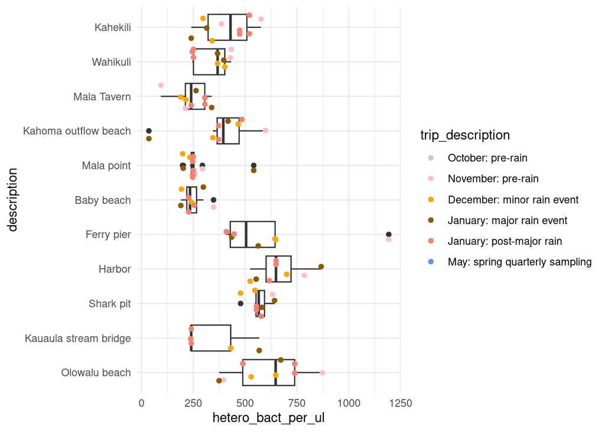

```r
ggplot(shore_dat, aes(x = description,
                      y = hetero_bact_per_ul))+
  geom_boxplot()+
  geom_jitter(aes(color = trip_description))+
  coord_flip()+
  scale_color_manual(values = color_pallete)
```

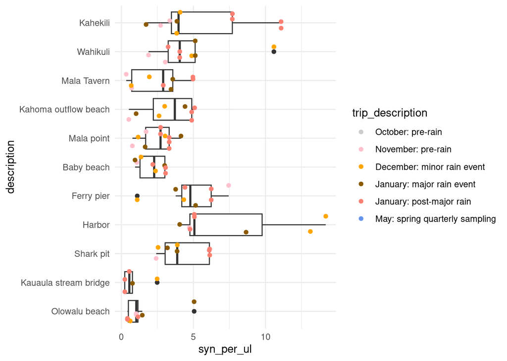

```r
ggplot(shore_dat, aes(x = description,
                      y = syn_per_ul))+
  geom_boxplot()+
  geom_jitter(aes(color = trip_description))+
  coord_flip()+
  scale_color_manual(values = color_pallete)
```

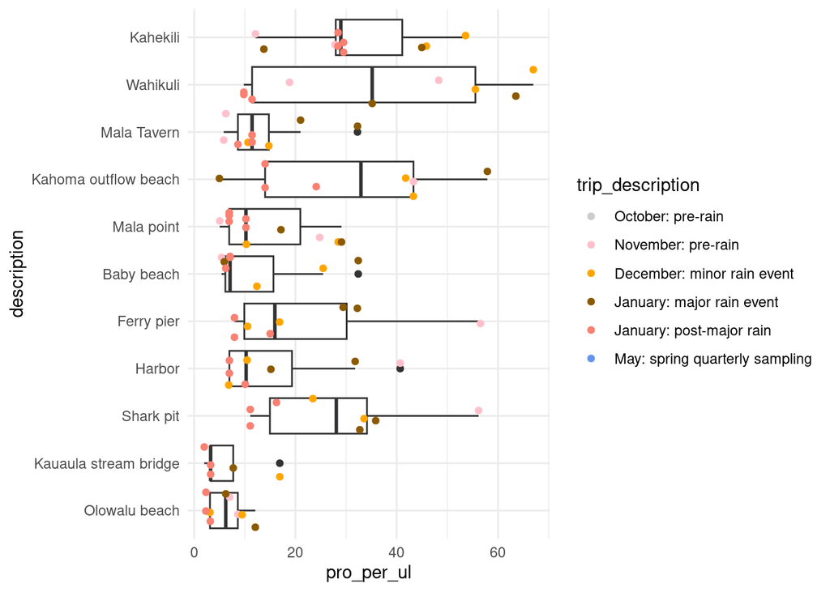

```r
ggplot(shore_dat, aes(x = description,
                      y = pro_per_ul))+
  geom_boxplot()+
  geom_jitter(aes(color = trip_description))+
  coord_flip()+
  scale_color_manual(values = color_pallete)
```

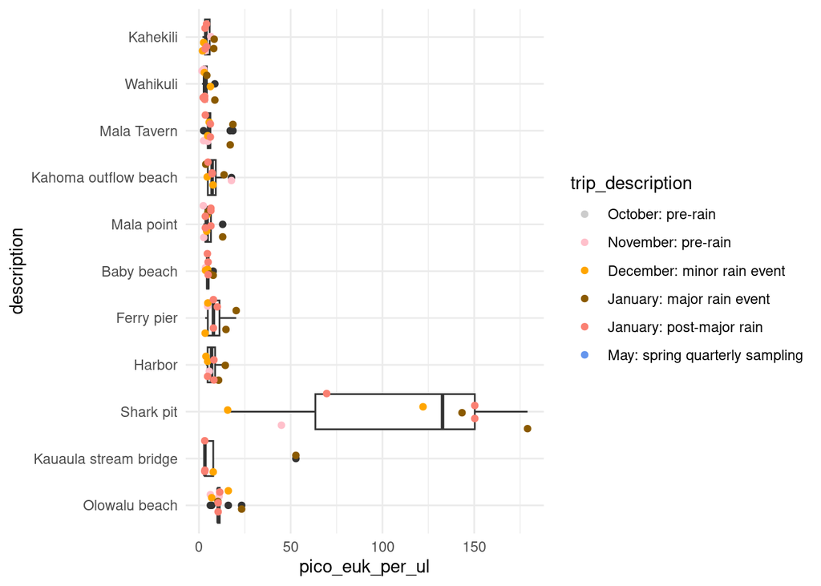

```r
ggplot(shore_dat, aes(x = description,
                      y = pico_euk_per_ul))+
  geom_boxplot()+
  geom_jitter(aes(color = trip_description))+
  coord_flip()+
  scale_color_manual(values = color_pallete)
```

Let’s focus on changes over time.

- Plot 1: heterotrophic bacteria over time
- Plot 2: synechococcus over time

Interpretation:

- heterotrophic bacteria numbers seem pretty consistent over time
- Synechococcus counts go up over time, possibly related to rainfall/runoff?

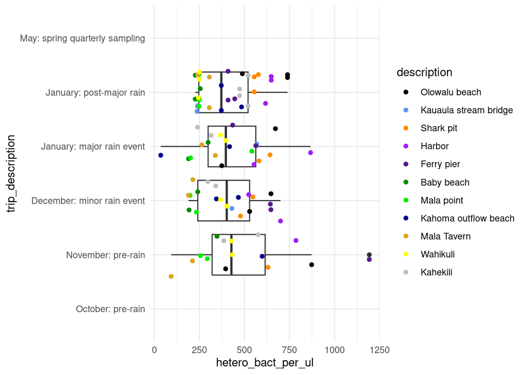

```r
ggplot(shore_dat, aes(x = trip_description,
                      y = hetero_bact_per_ul))+
  geom_boxplot()+
  geom_jitter(aes(color = description))+
  coord_flip()+
  scale_color_manual(values = color_pallete)
```

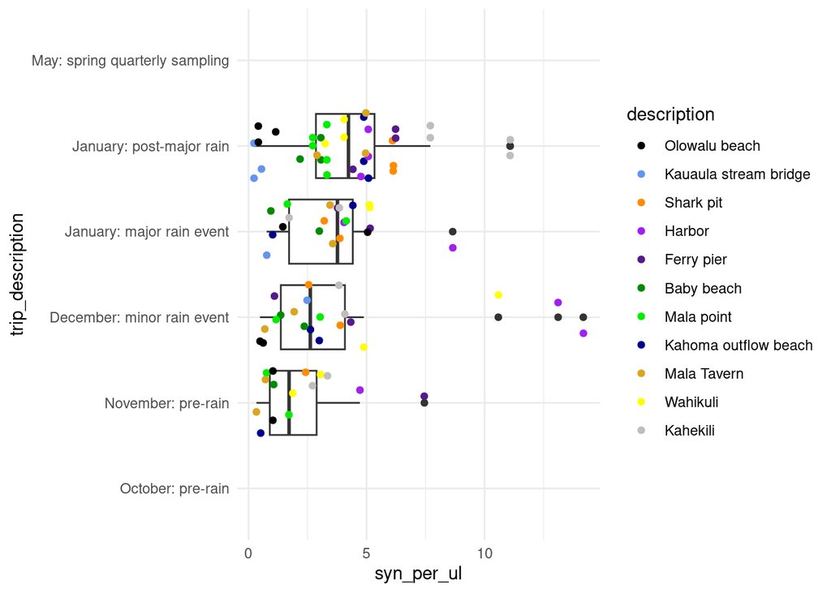

```r
ggplot(shore_dat, aes(x = trip_description,
                      y = syn_per_ul))+
  geom_boxplot()+
  geom_jitter(aes(color = description))+
  coord_flip()+
  scale_color_manual(values = color_pallete)
```

# fDOM

Quick check to see if fDOM matches any of the FCM data. I feel like it would be good to run PARAFAC but have not had time to do so yet. Mainly interested in humic substances and some of the ratios that indicate terrestrial vs. marine inputs of organic matter.

I have played around with other ways to plot these data, but for now I want to think about them in a very simple boxplot kind of way.

- Plot 1: Terrestrial humic substances (CobleC) by site
- Plot 2: Lignin by site
- Plot 3: BIX by site, “high values of BIX (>1) correspond to a predominantly autochthonous origin of DOM and to the presence of OM freshly released into water”
- Plot 4: FI by site, “1.9 for microbially derived fulvic acids and a value of 1.4 for terrestrially derived fulvic acids”

Interpretation

- Humics (CobleC) strongly related to proximity to freshwater streams
- Lignin, which is also supposed to be tracer of terrigenous input, seems higher in burn zone sites
- BIX actually seems to do a decent job identifying sites that have stronger marine or freshwater influence
- FI is in the right range, but seems a little weird. Kahoma stream should be more freshwater influenced. Quite a bit of variability between temporally close samples at the same site (e.g. kahekili).

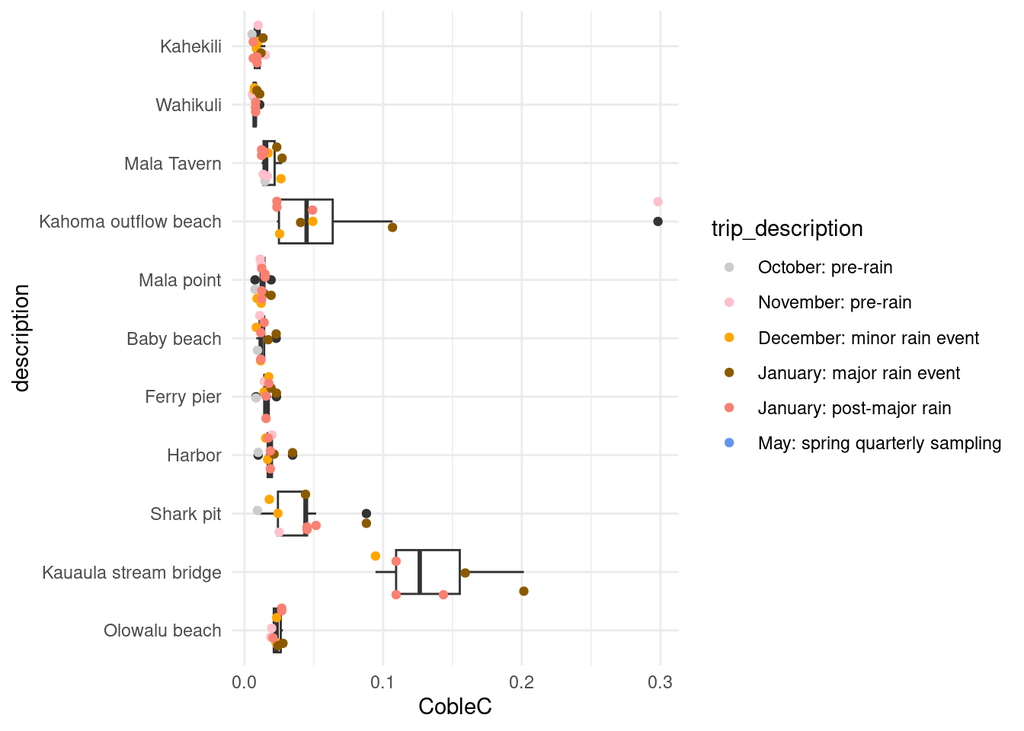

```r
ggplot(shore_dat, aes(x = description,
                      y = CobleC))+
  geom_boxplot()+
  geom_jitter(aes(color = trip_description))+
  coord_flip()+
  scale_color_manual(values = color_pallete)
```

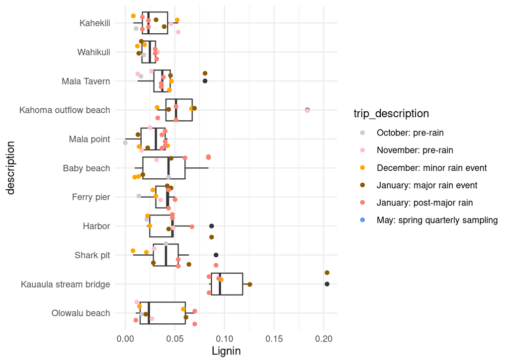

```r
ggplot(shore_dat, aes(x = description,
                      y = Lignin))+
  geom_boxplot()+
  geom_jitter(aes(color = trip_description))+
  coord_flip()+
  scale_color_manual(values = color_pallete)
```

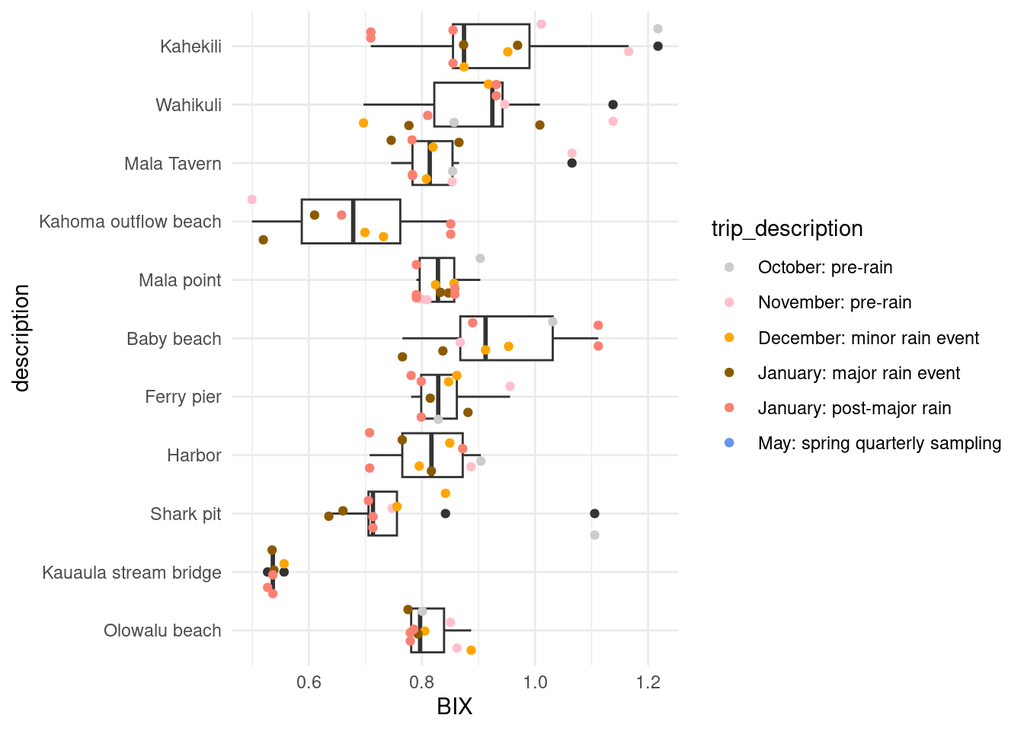

```r
ggplot(shore_dat, aes(x = description,
                      y = BIX))+
  geom_boxplot()+
  geom_jitter(aes(color = trip_description))+
  coord_flip()+
  scale_color_manual(values = color_pallete)
```

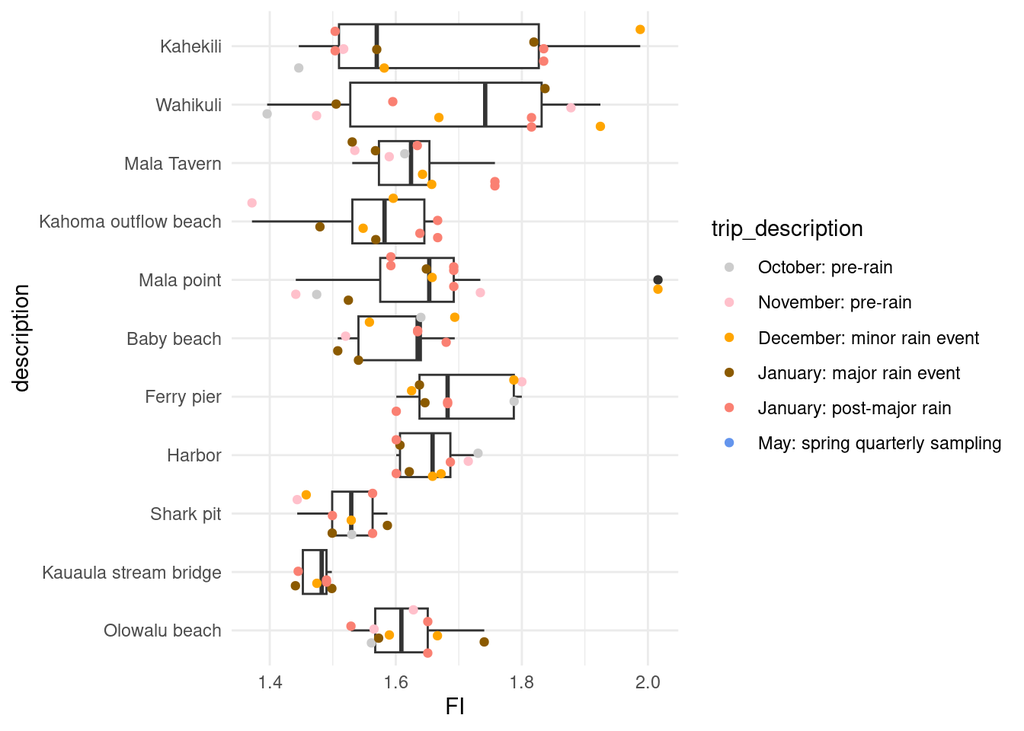

```r
ggplot(shore_dat, aes(x = description,
                      y = FI))+
  geom_boxplot()+
  geom_jitter(aes(color = trip_description))+
  coord_flip()+
  scale_color_manual(values = color_pallete)
```

Also check for trends by trip date (i.e. rainfall).

Yeah, fluorescence could be going up with rainfall. These plots are also influenced by the fact that we added Kahoma stream and Kauaula stream sampling sites in November and December, respectively. BIX decreases with rainfall. Interestingly, FI seems to be decoupled from BIX and indicates more microbial DOM production after rainfall.

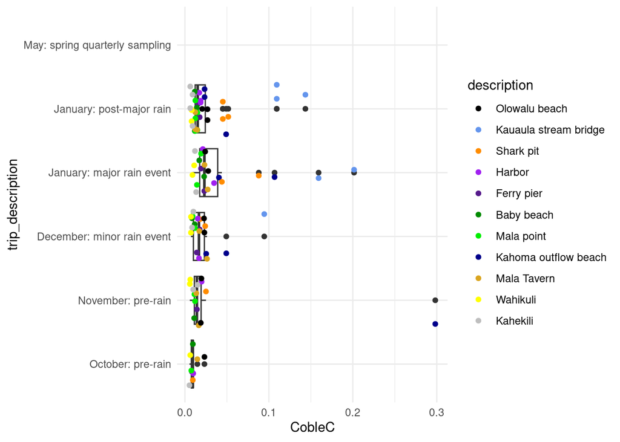

```r
ggplot(shore_dat, aes(x = trip_description,
                      y = CobleC))+
  geom_boxplot()+
  geom_jitter(aes(color = description))+
  coord_flip()+
  scale_color_manual(values = color_pallete)
```

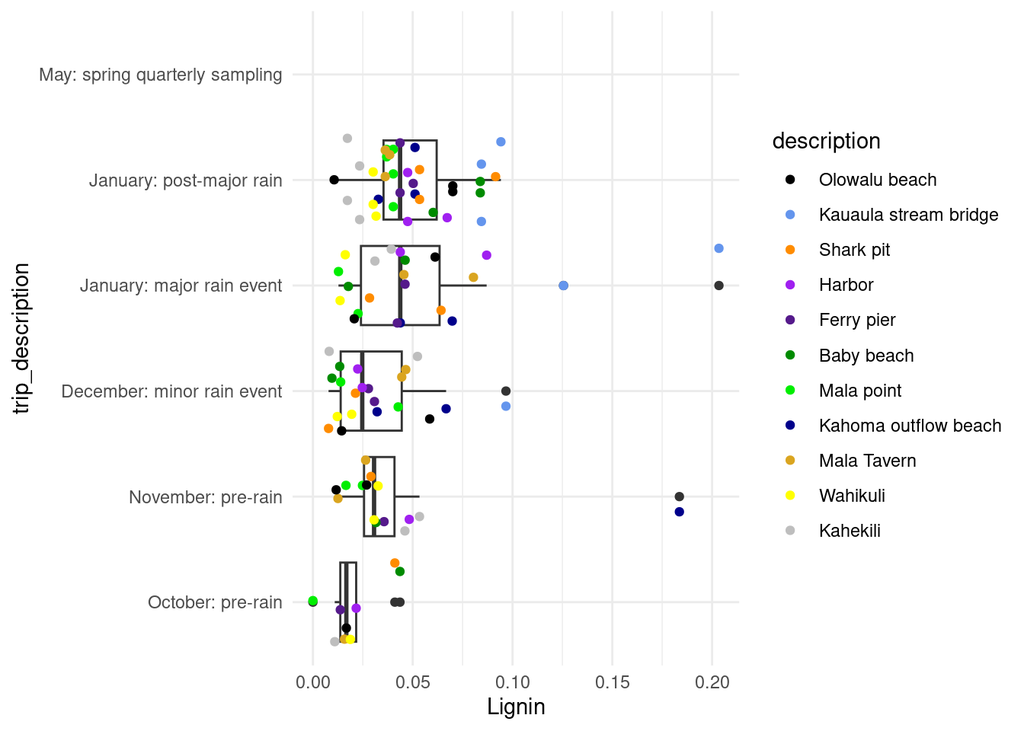

```r
ggplot(shore_dat, aes(x = trip_description,
                      y = Lignin))+
  geom_boxplot()+
  geom_jitter(aes(color = description))+
  coord_flip()+
  scale_color_manual(values = color_pallete)
```

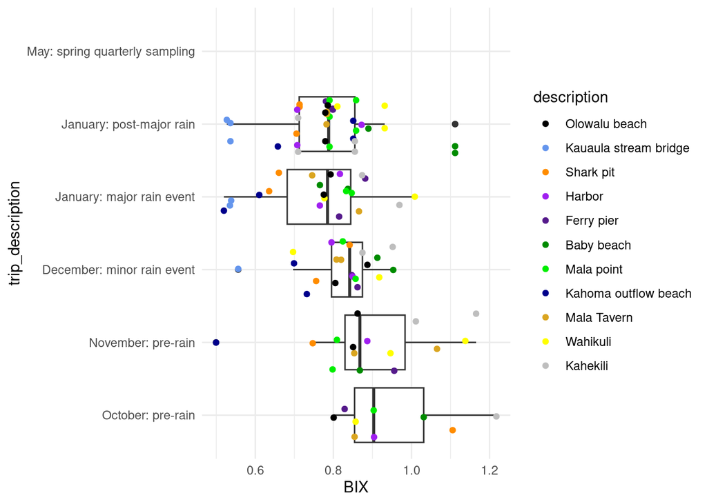

```r
ggplot(shore_dat, aes(x = trip_description,
                      y = BIX))+
  geom_boxplot()+
  geom_jitter(aes(color = description))+
  coord_flip()+
  scale_color_manual(values = color_pallete)
```

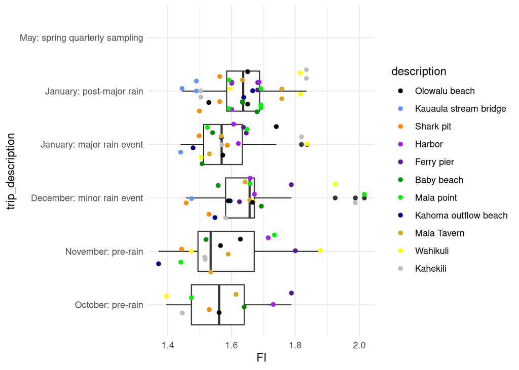

```r
ggplot(shore_dat, aes(x = trip_description,
                      y = FI))+
  geom_boxplot()+
  geom_jitter(aes(color = description))+
  coord_flip()+
  scale_color_manual(values = color_pallete)
```

*FIN*